# FINA 3000 · Business Finance I

Class 1 · Welcome & Chapter 1

Dr. Justin Mohr

August 25, 2026

## Roadmap

- Introductions
- Syllabus review
- Slides Use
- Chapter 1

# A little about me

## A little about me

- Born and raised a **Floridian**
- **PhD**, University of Illinois
  - Retail trading, household finance, fintech
- **Undergrad**, University of South Florida
  - Economics & econometrics
- Briefly in **venture capital** before the PhD

[figure not shown]

[figure not shown]

## More about y’all

Let’s go around the room, tell us your:

- Name
- Year
- Major
- A career path you might be interested in

# Why this course?

## The goal of the course

The broad goal of this course is to teach you to understand **financial management**.

> This course is an introduction to business finance. It emphasizes the financing and investment decisions of the financial manager: financial statements, cash flows, time value of money, valuation, risk, capital structure, and capital budgeting.

**Go read the syllabus!**

But more than that, I want to help you build an **intuition**.

## Scuba diving and finance

- I’m an avid **scuba diver** (≈115 dives, rescue diver)
- Dove Florida, the Caribbean, and recently **San Andrés**
- Open-water class on the boat got me thinking about… this class

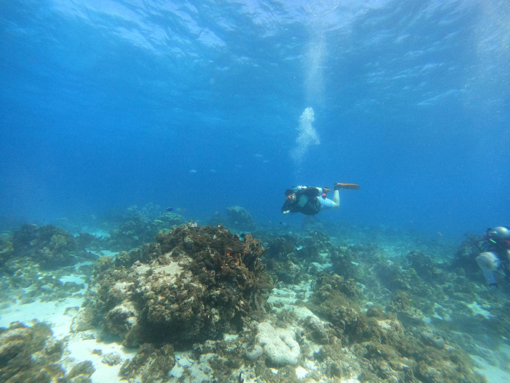

## Our instincts are often wrong

Especially when we do something **unnatural**: like breathing underwater, or thinking clearly about math and markets.

What’s our natural reaction to stress? **What kills you while scuba diving?**

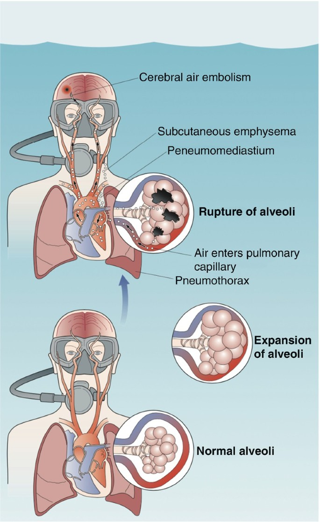

## What “kills” you in finance

- **Mental accounting bias**
  - “girl math / boy math”
- **Overconfidence**
  - Most investors think they’re above average → overtrading, poor diversification, misjudged risk
- **Familiarity bias**
  - Favoring what we know (buying your own company’s stock)
- **Not understanding interest & compounding**
  - The time value of money

## My additional goal for you

Degree and career path aside, you **must** interact with financial products and contracts.

Our concepts, while focused on businesses, overlap greatly with household finances.

By the end of this course, you will be able to:

- Price **auto loans and mortgages**
- Understand **risk and return** trade-offs
- **Discern financial scams**
- **Plan your retirement**: saving needs to start early!
- Begin to understand how to **invest**: diversification!

# Syllabus & logistics

## Communication & office hours

- **Email is best:** jjmohr1@olemiss.edu
- I reply within ~1 business day. Emails get lost, so don’t hesitate to follow up
  - If I do not get back to you in time, you get to send me an angry email
- **Office:** 325 Holman Hall · **Hours:** T TH 10:50A-12:20P (or email for another time)

## Emails & professionalism

You’re respectful and a joy to teach, **but** some emails need work! We’re in a business school, so let’s build professional habits now.

*We’ll walk through a rough template for a professional email.*

## A rough email template

- **Informative subject**: say what it’s about, concisely (**emails always have subjects**)
- **Greeting**: *Dear/Hello Dr. Lastname,* (academia) · *Dear Hiring Manager,* (business)
- **Body**: identify yourself, be brief and clear, spell-check
- **Closing**: a sign-off and your name (*Best, Your Name*)

## What you need

- **Textbook:** *Fundamentals of Financial Management, Concise Edition*, Brigham & Houston, 12th ed. (Cengage) with **MindTap**
- **Calculator:** TI **BA II Plus** (the only calculator allowed on exams)

## Grading

How your grade is computed

| Component | Weight |
| --- | --- |
| Exams (lowest score dropped) | **85%** |
| Homework (completion only; lowest 2 scores dropped) | **10%** |
| AI assignment | **5%** |

I do not assign plus/minus grades. Scale: **A** 90–100 · **B** 80–89 · **C** 70–79 · **D** 60–69 · **F** < 60

## Homework

- Administered via **MindTap**
- Due **Sundays at 11:59 PM**, after we finish the material
- **3 attempts**: a homework is complete with a nonzero score
- Graded for **completion**: give me a **non-zero score**
- The point is to get you to actually try the problems, rather than hand them to an AI
- **Lowest 2 scores dropped**

## Attendance

- Not required, but **rewarded**: **2 extra credit points** on your overall grade
- Strong correlation between showing up and performing well
- You may miss **2 classes** between the drop/add date and **Test 3** and still receive the attendance points
- Attendance points require **arriving to class on time**
- It is your responsibility to complete the attendance quiz at the **beginning** of class; raise any issue with it then
- Collected **online**, so bring a smartphone to scan the QR code
- I will be trialing a new system next class

## Exams

- **Best 3 of the 4.** The fourth exam is the cumulative final, so your lowest score drops
- No hats, no phones, no calculators other than the **BA II Plus**
- I have a **zero tolerance** policy for academic integrity

## Electronics on exam day

**Bags go on the wall.**

- During an exam, the only electronics allowed on your person are your calculator and any device you have a specific accommodation for from SDS.
- All other electronics must be silenced and left in your bag at the side of the room.
- This includes but is not limited to headphones, smart glasses, smart watches, smart rings, and regular watches.
- Unless specifically exempted, anything with the ability to control the flow of electrons other than a BA II plus is not allowed.

**If you have an SDS accommodation, talk to me. That is the exemption.**

## Exam schedule

Exam schedule

| Exam | Date | Covers |
| --- | --- | --- |
| **Test 1** | Thu Sep 17 | Ch 1, 3, 4, 17, 5 |
| **Test 2** | Thu Oct 15 | Ch 7, 8, 9 (part 1) |
| **Test 3** | Tue Nov 17 | Ch 9 (part 2), 10, 11, 12 |
| **Final (optional)** | Dec 7-11 | Cumulative |

Dates are also on the syllabus. Changes are announced in class and on Blackboard.

**If you need SDS accommodations, schedule them now.**

## Final grade

- When assigning the final letter grade, prior exam and homework grades are **not open to reassessment**
- If you believe an exam was incorrectly graded, bring it to my attention **within 2 weeks** of the grade being posted on Blackboard

## Policies that save lives!

Your grandparents are very dear to me.

- For that reason I try to be generous **by design**: 2 homework drops and 1 exam drop are already built in
- Homework due Sundays; the exam schedule is in the syllabus; **no make-up exams**
- I **will not** deviate from the syllabus, even when I’d like to

## AI use

What experience do you all have with it?

## Preparing for class

- **Read the assigned chapters.** You’re responsible for all the material in the chapter, even if we don’t explicitly cover it in class
  - There will be some homework questions about material we won’t explicitly cover for **Ch 3 and 4**. I will only test on topics covered in class for those chapters.
- **Recall prior material**: Unit 1 assumes you’re comfortable with Accounting 201 and 202
- Adaptive test prep, end-of-chapter problems, and practice quizzes for select chapters
- **The key to this class is practice!** Concepts require practice to build an intuition

## Course material builds on itself

Starting with **Ch 5** we build on each concept. What this means for you:

- **Absences are costly**: find me to get back on track
- **Concepts will not go away.** If you’re confused on a topic, get help **ASAP**
- **Chapter 5** concepts show up on **4 of our 4 exams**
- **The last month is not the time to check back in**: concepts will be hard to catch up on

## Help

- I am here to help! Come to **office hours** or **email** me. I have lots of materials to help you practice
- The **PhD students hold review sessions**; I’ll send you the schedule
- This is a course that **rewards effort**
- Slides are posted **without answers** before class so you can work the problems; full slides go up after class *(if I forget to upload them, please ask me to!)*

## Using the slides

- The slides are embedded in Blackboard. **Click once inside them**, then press **F** for full screen, and **Esc** to come back out
- Move with the **arrow keys** or **space**; **O** shows every slide at once; **?** lists every shortcut
- To keep your own copy, **right-click the slides** and choose **Open frame in new tab**
- Then press **E** for the print layout, **Ctrl+P** (**Cmd+P** on a Mac), and set **Layout: Landscape**, **Margins: None**, tick **Background graphics**, and choose **Save as PDF**

# Chapter 1 · Financial Management

## Three Areas

- **Financial Management**
  - What do we do and how do we do it
  - Main focus of this course
- **Capital Markets**
  - Market firms go to for capital
- **Investments**
  - Valuing and structuring securities
- Each are interconnected!
  - If I want to raise capital for a project, then I need to understand how to raise it and how to price it

## Goal of Financial Management

- What should we do! How should we do it!
- Later in this course we will go over how to choose projects, and we will discuss how firms find funding.
- How do we choose what to do?

## Forms of Businesses

What are different ways to organize a business?

## Sole Proprietorship

- Easy to form
- Single owner who is also the manager
- Taxed at the owner’s individual tax rate
- What might be some disadvantages of this?

## Disadvantages of Sole Proprietorships

- **Unlimited liability**
  - Why is this an issue?
- **Hard to transfer ownership**
  - The company and the individual are the same!
- **Difficult to raise capital**
  - Can you finance through equity?
  - What about debt?

What about the Sole part?

## Partnerships

- **General partnerships**
  - Same as a proprietorship, but multiple people
  - Still unlimited liability
- **Limited partnerships**
  - Run by managing or general partners who have unlimited liability
  - Limited partners are passive investors
    - Limited liability and no management role

What are some examples of these?

## Corporations

What is special about a corporation compared to the other forms we discussed?

## Corporations

What advantages does this give corporations?

## Corporations

When do owners stop having limited liability with a corporation?

## Corporations

Other disadvantages?

## Comparison of the forms of business

Comparison of the forms of business

|  | Sole proprietorship | Partnership | Corporation |
| --- | --- | --- | --- |
| Business owner | Single owner | Partners | Shareholders |
| Owner’s liability | Unlimited | Unlimited | **Limited** |
| Easy access to capital market? | No | No | **Yes** |
| Is management and ownership separate? | No | No | **Yes** |
| Are business owners exposed to double taxation? | No | No | **Yes** |

## LLCs and LLPs

- **LLPs**
  - Limited liability and pass through
  - Management is divided due to ownership
  - Not responsible for partners negligence
  - Examples?
    - Doctors offices, dentists, law firms, CPAs
- **LLC**
  - Can choose how to be taxed
  - Limited liability
  - Lots of differences across states

## Manager vs. Shareholders

What could be the problem here?

## Manager vs. Shareholders cont.

- What could be the problem here?
  - Managers best interest is not that of the firm!
- How can I keep my manager working?
  - Managerial compensation packages
  - Direct intervention by shareholders
  - The threat of firing
  - The threat of takeover
- Inherent timing problem
  - I can’t reward based on the future, so packages are based in the present
  - Manipulation

## Management’s Goal

Management’s goal should be to take actions designed to maximize the firm’s intrinsic value, not its current market price.

## Intrinsic Value

[figure not shown]

## Debt holders and shareholders

In good times, when the firm earns excess profits, what does each one get? In bad times, when the firm fails, what does each one get?

## Shareholders vs. debt holders

- An extreme example: There is a project that has a 40% chance of failing and bankrupting the firm but a possible 200% return
  - How would a shareholder feel about this?
  - A debt holder?
- Debt holders do not share in the upside, whereas shareholders do!
- Why do bond holders dislike additional debt?
  - It decreases their likelihood of repayment!
- What can a bond holder do to exert control?
  - Covenants. What are some real world examples?

## Covenants in the real world

> A growing number of colleges are breaching bond and loan stipulations, known as covenants, that require them to stay within certain financial health parameters, according to a new report from S&P Global Ratings. The agency cited 12 colleges it rates that have breached covenants since last June.

> In most cases, bondholders waived the violation. Some covenants could allow debtholders to accelerate repayment, which could add to an institution’s liquidity and ratings risks.

[More colleges are breaching their debt requirements: S&P](https://www.highereddive.com/news/colleges-loan-covenant-violations-bonds-sp/719691/), Ben Unglesbee, *Higher Ed Dive*, June 25, 2024

# Wrap-up

## Before next class

- **Review accounting and financial statements**
- **Read Chapter 3** before next class

## Upcoming Dates

Upcoming class dates and deadlines

| Date | Topic | Due / Notes |
| --- | --- | --- |
| Thu Aug 27 | Chapter 3; Chapter 4 | - |
| Tue Sep 1 | Chapter 4; Chapter 17 | - |
| Thu Sep 3 | Chapter 5: Time Value of Money | - |
| Fri Sep 4 | Last day to register or add classes | DEADLINE |

**Office:** 325 Holman Hall · **Office hours:** T TH 10:50A-12:20P · jjmohr1@olemiss.edu